# Valence Shifters for Sentiment-An

### Sentiment analysis with sentimentR

Loading required libraries

```r
if (!require(sentimentr)) {install.packages("sentimentr")} # ensure java is up to date!
library(sentimentr)
library(dplyr)
```

```r
library(ggplot2)   # for visualizing sentimt variation
```

#### Sentiment scoring using valence shifters

SentimentR uses valence shifters (i.e., *negators*, *amplifiers* (intensifiers), *de-amplifiers* (downtoners), and *adversative conjunctions* to compute the score, which change the meaning but are not taken into account by usual dictionary based packages.

Behold a simple example.

```r
sent1 <- "I like to learn new things"
sent2 <- "I not so much like to learn new things"

sentiment(sent1)
```

```
##    element_id sentence_id word_count sentiment
## 1:          1           1          6 0.8573214
```

```r
sentiment(sent2)
```

```
##    element_id sentence_id word_count sentiment
## 1:          1           1          9 0.3933333
```

### Valence Shifters in action

Consider a list of simple-ish sentences and how `sentimentr` treats the various valence shifters contained therein.

To see what valence shifters are available in the `lexicon` package, run the following:

```r
require(lexicon)
hash_valence_shifters
```

```
##               x y
##   1: absolutely 2
##   2:      acute 2
##   3:    acutely 2
##   4:      ain't 1
##   5:       aint 1
##  ---
## 136:    whereas 4
## 137:      won't 1
## 138:       wont 1
## 139:   wouldn't 1
## 140:    wouldnt 1
```

```r
hash_valence_shifters[y==1][1:8]  # to see top 8  negators
```

```
##           x y
## 1:    ain't 1
## 2:     aint 1
## 3:   aren't 1
## 4:    arent 1
## 5:    can't 1
## 6:   cannot 1
## 7:     cant 1
## 8: couldn't 1
```

```r
hash_valence_shifters[y==2][1:8]  # to see amplifiers wala list
```

```
##               x y
## 1:   absolutely 2
## 2:        acute 2
## 3:      acutely 2
## 4:      certain 2
## 5:    certainly 2
## 6:     colossal 2
## 7:   colossally 2
## 8: considerably 2
```

```r
hash_valence_shifters[y==3][1:8]  # for de-amplifiers list
```

```
##             x y
## 1:     almost 3
## 2:     barely 3
## 3:    faintly 3
## 4:        few 3
## 5:     hardly 3
## 6: incredibly 3
## 7:    kind of 3
## 8:      kinda 3
```

```r
hash_valence_shifters[y==4]   # for adversative conjunctions
```

```
##                   x y
## 1:         although 4
## 2:              but 4
## 3: despite all that 4
## 4: despite all this 4
## 5:     despite that 4
## 6:     despite this 4
## 7:          however 4
## 8:  that being said 4
## 9:          whereas 4
```

```r
sentiment("I like it.")  # simple sent
```

```
##    element_id sentence_id word_count sentiment
## 1:          1           1          3 0.2886751
```

```r
sentiment("I don't like it.")  # negation
```

```
##    element_id sentence_id word_count sentiment
## 1:          1           1          4     -0.25
```

```r
sentiment("I hate it.")   # simple sent
```

```
##    element_id sentence_id word_count  sentiment
## 1:          1           1          3 -0.4330127
```

```r
sentiment("I don't hate it.")  # negation
```

```
##    element_id sentence_id word_count sentiment
## 1:          1           1          4     0.375
```

```r
sentiment("But I don't hate it.")  # negation with adverserial conjunction
```

```
##    element_id sentence_id word_count sentiment
## 1:          1           1          5 0.7546729
```

#### De-amplifiers or downtoners

I’d expect de-amplifiers like may, somewhat, sort of etc. to dampen the sentiment score of a sentence. Let’s see whether and to what extent that happens.

```r
sentiment("I not like it.")   # another negation
```

```
##    element_id sentence_id word_count sentiment
## 1:          1           1          4     -0.25
```

```r
sentiment("I may not like it.")  # negation with a de-amplifier
```

```
##    element_id sentence_id word_count  sentiment
## 1:          1           1          5 -0.2236068
```

```r
sentiment("I almost don't like it.")  # negation with a de-amplifier
```

```
##    element_id sentence_id word_count   sentiment
## 1:          1           1          5 -0.04472136
```

```r
sentiment("I hardly like it.")    # de-amplifier or downtoner
```

```
##    element_id sentence_id word_count sentiment
## 1:          1           1          4      0.05
```

```r
sentiment("I sort of like it.")   # more de-amplifier or downtoner
```

```
##    element_id sentence_id word_count sentiment
## 1:          1           1          5         0
```

```r
sentiment("I somewhat like it.")  # more de-amplifier or downtoner
```

```
##    element_id sentence_id word_count sentiment
## 1:          1           1          4      0.05
```

#### Amplifiers or intensifiers

Amplifiers like ‘really’, ‘absolutely’, ‘surely’ etc. will intensify the valence in a sentence.

```r
sentiment("I really like it.")   # amplifier or intensifier
```

```
##    element_id sentence_id word_count sentiment
## 1:          1           1          4      0.45
```

```r
sentiment("I never like it.")   # negation + amplifier
```

```
##    element_id sentence_id word_count sentiment
## 1:          1           1          4     -0.25
```

```r
sentiment("I sure like it.")   # straight amplifier
```

```
##    element_id sentence_id word_count sentiment
## 1:          1           1          4      0.45
```

#### Repeat negations

```r
sentiment("I'm not happy.")    # single negation
```

```
##    element_id sentence_id word_count  sentiment
## 1:          1           1          3 -0.4330127
```

```r
sentiment("I'm not unhappy.")  # double negation
```

```
##    element_id sentence_id word_count sentiment
## 1:          1           1          3 0.4330127
```

```r
sentiment("I don't feel not unhappy.")   # triple negation!
```

```
##    element_id sentence_id word_count  sentiment
## 1:          1           1          5 -0.3354102
```

#### Adversative conjunctions

```r
sentiment("But I don't like it.")  # Adversative conjunction + negation
```

```
##    element_id sentence_id word_count  sentiment
## 1:          1           1          5 -0.5031153
```

```r
sentiment("I didn't like it but now I like it.")   # adversative conjunction
```

```
##    element_id sentence_id word_count sentiment
## 1:          1           1          9 0.3748333
```

```r
sentiment("I didn't like it and now I like it.")   # non-adversative conjunction
```

```
##    element_id sentence_id word_count sentiment
## 1:          1           1          9         0
```

So what all did we see above?

### Analyzing groups of sentences

Sometimes we want to analyse the sentences as a group rather than a single sentence. We can use the `sentiment_by()` function to group the sentences according to a criteria. It averages the sentiment from each sentence and outputs an aggregated value

```r
sent3 <- "I hate reading. But I love comic books."

sentiment(sent3)
```

```
##    element_id sentence_id word_count  sentiment
## 1:          1           1          3 -0.3752777
## 2:          1           2          5  0.7546729
```

```r
sentiment_by(sent3)
```

```
##    element_id word_count        sd ave_sentiment
## 1:          1          8 0.7989957     0.1896976
```

### Extracting words from score calculation

We can extract the words which were used for polarity calculation and also the polarity they contributed.

```r
sent3   # view sent3 again
```

```
## [1] "I hate reading. But I love comic books."
```

```r
words <- extract_sentiment_terms(sent3)

attributes(extract_sentiment_terms(sent3))$elements
```

```
##    element_id sentence_id   words polarity
## 1:          1           1       i     0.00
## 2:          1           1    hate    -0.75
## 3:          1           1 reading     0.10
## 4:          1           2     but     0.00
## 5:          1           2       i     0.00
## 6:          1           2    love     0.75
## 7:          1           2   comic     0.00
## 8:          1           2   books     0.00
```

### Applying to Nokia dataset

How about we apply this to a size-able dataset and not just a few small sentences here and there, eh?

Plan next is to apply the above to the Nokia Lumia reviews dataset.

```r
nokia = readLines('https://github.com/sudhir-voleti/sample-data-sets/raw/master/text%20analysis%20data/amazon%20nokia%20lumia%20reviews.txt')

review1 = nokia[1]   # try first review
sentiment_by(review1)  # get aggregate polarity for the whole review
```

```
##    element_id word_count       sd ave_sentiment
## 1:          1        423 0.372013     0.2655574
```

```r
# get polarity by indiv sentence
a0.df = review1 %>%
    get_sentences() %>% # inbuilt sentence-parsing
    sentiment()    # sentiment for each sentence parsed
a0.df
```

```
##     element_id sentence_id word_count   sentiment
##  1:          1           1         23 -0.13032151
##  2:          1           2         55  0.37080992
##  3:          1           3         23  1.07384923
##  4:          1           4         40  0.27669930
##  5:          1           5         24  0.52051657
##  6:          1           6         39  0.25620505
##  7:          1           7         84  0.29786742
##  8:          1           8         37  0.68225580
##  9:          1           9         56  0.02004459
## 10:          1          10         19 -0.24776899
## 11:          1          11         15  0.15491933
## 12:          1          12          8 -0.08838835
```

```r
# get aggreg polarity for the whole corpus
system.time({ nokia_senti = sentiment_by(nokia) })  # 0.39 secs
```

```
##    user  system elapsed
##    0.61    0.04    0.67
```

```r
nokia_senti[1:15,]    # view first 15 rows
```

```
##     element_id word_count        sd ave_sentiment
##  1:          1        423 0.3720130    0.26555736
##  2:          2        517 0.3470145    0.38225896
##  3:          3        323 0.2560640    0.25550177
##  4:          4        101 0.1999131    0.36400051
##  5:          5        354 0.3845797    0.35866699
##  6:          6        458 0.2798667    0.07156705
##  7:          7         64 0.2149912    0.03425437
##  8:          8        336 0.3872232    0.34279928
##  9:          9        163 0.2720118    0.06086719
## 10:         10         57 0.4243636    0.35988667
## 11:         11        480 0.2032872    0.25488575
## 12:         12        254 0.3346242    0.14056631
## 13:         13        390 0.2290323    0.47240608
## 14:         14        248 0.2289725    0.25562258
## 15:         15         30 0.2801002    0.28385364
```

### Visualizing Sentiment over Doc length

How might sentiment levels vary over the length of a document? Is there an upward trend? downward trend? No trend? How to know? HOw better in fact, than to visualize the same and see for ourselves?

Am using ggplot2 below. Code is straightforward to follow.

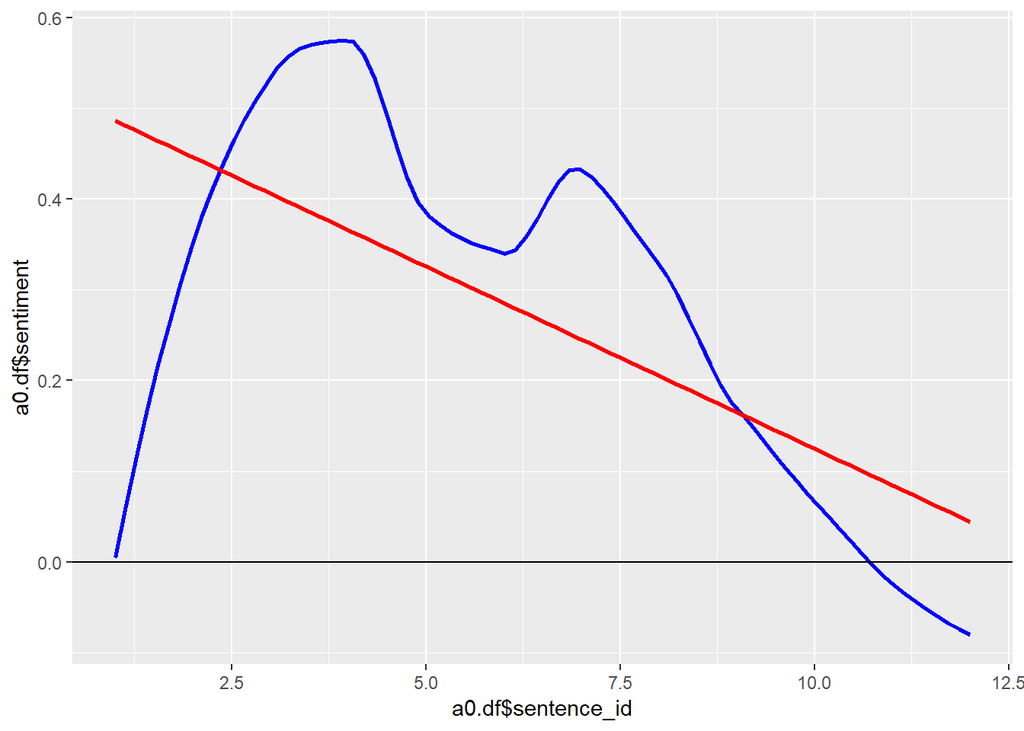

```r
require(ggplot2)
p <- ggplot(a0.df, aes(x = a0.df$sentence_id, y = a0.df$sentiment)) +
geom_smooth(col="blue", se=FALSE) + geom_hline(yintercept=0) +
geom_smooth(method="lm", formula=y~x, col="red", se=FALSE)
p
```

Closing with that for now.

Ciao

Sudhir